# Use of Intensifying Adverbs in Historical Spoken English

Susan Huotari

susan.huotari@helsinki.fi

3.3.2017

Abstract

This study discusses the use of intensifying adverbs as recorded in the *Old Bailey Corpus* covering a time period from 1720 to 1820. The topic is approached from a statistical point of view by fitting a logistic regression model as well as applying a multiple correspondence analysis. In this study I argue that although there is a strong connection between the use of derived intensifiers and a higher social standing, social class alone is not enough and should not be used as the only predictor. Instead, other variables, such as time and gender, must be taken into consideration as well.

```r
knitr::opts_chunk$set(
  tidy = FALSE,
  size = "small",
  out.width = "70%",
  fig.align = "center",
  fig.width = 6,
  fig.asp = 0.618,
  fig.show = "hold",
  fig.path = "../figures/document/",
  cache.path = "../cache/document/",
  cache = TRUE,
  par = TRUE,
  collapse = TRUE,
  message = FALSE,
  warning = FALSE
)

options(digits = 3)
options(table_counter = TRUE)
```

```r
library(dplyr)
library(plyr)
library(lme4)
library(vcd)
library(tidyverse)
library(readr)
library(scales)
library(rms)
library(broom)
library(pander)
library(gridExtra)
library(GGally)
library(effects)
library(knitcitations)
library(stats)
library(htmlTable)
library(MASS)
library(ggplot2)
library(boot)
library(FactoMineR)
library(factoextra)
library(corrplot)
```

# 1 Introduction

Contemporary studies (Macaulay 2002) of spoken English have found a difference in the use of adverbs and the speaker’s social class with middle-class speakers using derived adverbs (i.e. ending in *-ly*) more than twice as frequently as working-class speakers. Macaulay concludes that this prominent difference is a reflection of different attitudes in these two social classes.

In the most narrow sense, intensifiers can be defined as adverbs whose function is to express the degree of the gradable adjective which they modify, e.g. *very good*, or *extremely interesting*. Intensifiers can scale a given property up (amplifiers) or down (diminishers).

The aim of this study is to find out how intensifying adverbs were used in historical spoken language. This will be done in three stages. First, following Macaulay’s study, I will investigate whether a distinction between the use of intensifying adverbs and social class can be identified in 18th-century courtroom discourse. After this, I will broaden the scope and fit a logistic regression model in order to predict the use of derived adverbs as intensifiers. Finally, I will further evaluate the logistic model and visualize the data by means of multiple correspondence analysis.

Given that the data deals with 18th-century English courtroom data, and that this was an era when social rank mattered a great deal (not least in terms of education), my hypothesis is that a relationship between the use of adverbs and social class can be established. However, I do not believe that this distinction was a constant one.

# 2 Materials

## 2.1 The *Old Bailey Corpus*

The data for this study was originally collected from the *Old Bailey Corpus* (Huber et al. 2012) (OBC). It is based on the *Proceedings of the Old Bailey* - a collection of accounts of criminal trials held at the Old Bailey, London’s central criminal court. OBC consists of a selection of speech events derived from the *Proceedings* covering nearly 200 years - from 1720 to 1913 - and contains some 14 million spoken words.

The corpus has been part-of-speech tagged using the CLAWS7 tag set. Each speech event has been further annotated, as far as it is possible to do so, for the following information:

- sociobiographic speaker information (gender, age, occupation, social class)
- pragmatic information (speaker’s role, i.e. defendant, judge, victim, witness etc.)
- textual information (scribe, printer, publisher)

Regardless of the abundance of material, the *Proceedings* are not complete accounts of what went of and what was said in the courtroom (Langbein 2005). They were subject to omissions, paraphrasis and even human error. But historical (un)reliability does not automatically indicate linguistic (un)reliability (Huber 2007). According to Huber, although there are issues concerning balance and interference, the speech events represented in the *Old Bailey Corpus* are as close as we can get to the spoken word of the period.

back to top

## 2.2 Collecting the data (*a priori*)

The data was collected prior to the current study. It was done by searching for adverb + adjective pairs between 1720 and 1819 in the OBC, and the results were then copied into Excel where they were refined and categorized. In the first phase false hits were identified and excluded from data set. False hits include cases where the adjectives were marked correctly as such but they were part of a street name, for example ‘Red [Lion-street]’ (information in square brackets added by me). Then varying spelling conventions (e.g.extremely / extreamly) were accounted for and standarized to their modern spelling forms. In the second phase the results were categorized. Speakers were marked according to their social class (higher vs lower) based on recommendations of the corpus compilers, and adverbs were categorized according to the type of adverb in question (derived vs simple) and whether its function was to intensify the following adjective or not.

back to top

## 2.3 Wrangling in R

For the purposes of this current study, I began by modifying the data in R. In the beginning it consisted of 23 variables and a total of 7,828 observations. First, I filtered the data set so as to include only those observations where adverbs were functioned as intensifiers, which decreased the data set by some 2,000 observations. Many of the variables were metadata from the corpus that were not relevant for my study (e.g. scribe, printer and publisher), or had become redundant after the data had been categorized (e.g. the original query item and its context information). The original data set also included variables such as age and age group which contained very few values (over 7,000 NA’s in both). I chose not to include these variables at all, because had I done so and then removed NA’s, I would have thrown the baby out with the bath water, as it were. Thus, only eight variables were chosen for the final data set (described below in section 2.4). So, working with the eight variables, I removed NA’s from the data set which left me with a total of 4,667 observations. After this I modified the variable names and value labels to make them more uniform and easier to work with, and saved the data set into a new file in the data folder. Here is the link to my [wrangling script](https://github.com/Tvistur/IODS-final/blob/master/data/create_adverbs.R).

back to top

## 2.4 Introducing the variables

```r
adverbs <- read.csv("data/adverbs.csv", sep = ",", header = TRUE, na.strings = c("", "NA"))
```

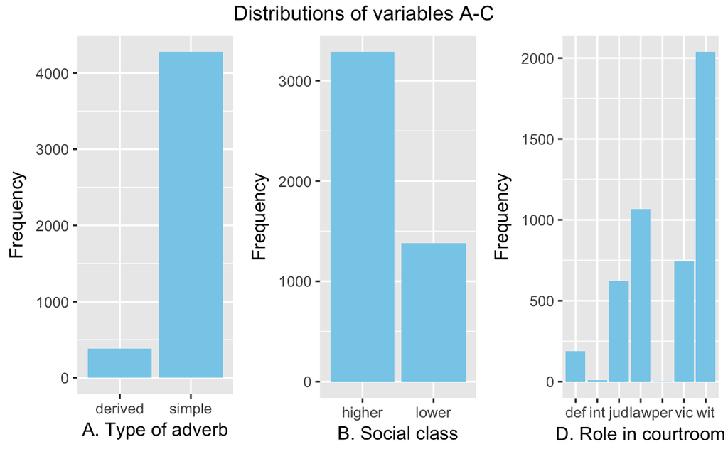

```r
adv <- ggplot(adverbs, aes(x = adverb_type)) +
  geom_bar(fill = "skyblue") +
  labs(x = "A. Type of adverb", y = "Frequency")

class <- ggplot(adverbs, aes(x = class)) +
  geom_bar(fill = "skyblue") +
  labs(x = "B. Social class", y = "Frequency")

role <- ggplot(adverbs, aes(x = role)) +
  geom_bar(fill = "skyblue") +
  labs(x = "D. Role in courtroom", y = "Frequency")

grid.arrange(adv, class, role, ncol = 3, top = "Distributions of variables A-C")
```

```r
# only derived intensifiers
derived <- adverbs %>% filter(adverb_type == "derived")
# only simple intensifiers
simple <- adverbs %>% filter(adverb_type == "simple")

# top 5 derived adverbs
sort(table(derived$adverb), decreasing = TRUE)[1:5]
##
##  perfectly  extremely   entirely    totally positively
##        149         61         24         18         16
# top 5 simple adverbs
sort(table(simple$adverb), decreasing = TRUE)[1:5]
##
##  very    so quite   too  more
##  2643   724   367   154   137
```

B. Social class:  
Speakers have been divided into two social classes, higher and lower, as explained in section 2.2. The fact that the majority of speakers come from the higher class is somewhat surprising. Judges and lawyers naturally belong to the this group but that does not explain the difference between the classes. One explanation could be the types of offences included in this data. Offences dealt with at the Old Bailey varied from pocket picking to royal offences. Although the former were more common and were more likely to involve members of the lower class, it could be that this data does not represent the typical distribution of offences. The offence category is not included in the OBC metadata so this matter will remain unknown as far as this study is concerned.

C. Role in courtroom:  
The courtroom involves various roles and most of the interaction occurs between witnesses (wit) and lawyers (law). The latter increased their presence in the English courtroom during the 18th century, and before their arrival judges (jud) acted in a somewhat similar role. On the other hand, defendants (def) were for the most part left to defend themselves (especially in murder trials in which they were actually not allowed defense counsel until the 1730s) and you would expect them to be very vocal, but due to various reasons that is not at all the case. The data set contains also some instances spoken by interpreters (int) and an unidentified person (per), most likely a member of the audience making a random unauthorized remark.

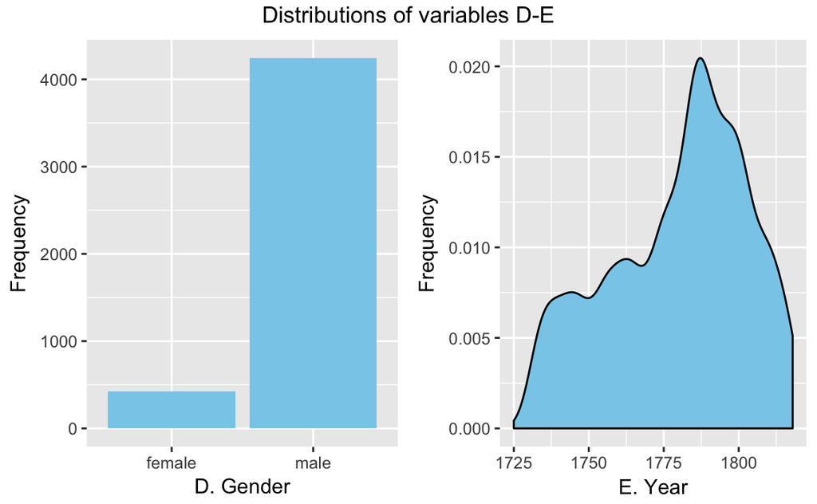

```r
gender <- ggplot(adverbs, aes(x = gender)) +
  geom_bar(fill = "skyblue") +
  labs(x = "D. Gender", y = "Frequency")

year <- ggplot(adverbs, aes(x = year)) +
  geom_density(fill = "skyblue") +
  labs(x = "E. Year", y = "Frequency")

grid.arrange(gender, year, ncol = 2, top = "Distributions of variables D-E")
```

D. Gender:  
This data set, as is the case with the *Proceedings* (Huber 2007), does not represent men and women equally. The 18th-century justice system was male dominated which can also be seen in the figure above. Women were most likely to appear in the courtroom as victims or witnesses. Furthermore. the majority of defendants were men as well - not only because fewer crimes were committed by women, but because fewer women were brought to trial (Beattie 2002).

```r
summary(adverbs$year)
##    Min. 1st Qu.  Median    Mean 3rd Qu.    Max.
##    1720    1760    1790    1780    1800    1820
```

Let us next put the roles together with gender and social class to confirm the previous interpretations. As we can see in the figure below, court officials (judges, lawyers and interpreters) are completely male dominated and none of these roles are present in the right-hand chart which represents roles held by women. Court officials also belong to the higher class, as do most of male witnesses whereas women represent more lower class speakers.

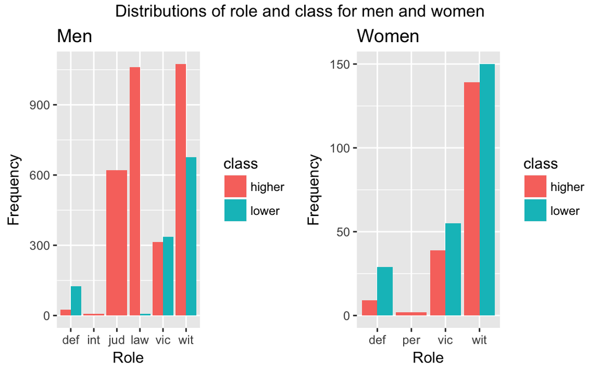

```r
# only men
men <- adverbs %>% filter(gender == "male")
# only women
women <- adverbs%>% filter(gender == "female")

role_class_m <- men %>%
  ggplot(aes(x = role)) +
  geom_bar(aes(fill = class), position = "dodge") +
  labs(x = "Role", y = "Frequency") +
  ggtitle("Men")

role_class_f <- women %>%
  ggplot(aes(x = role)) +
  geom_bar(aes(fill = class), position = "dodge") +
  labs(x = "Role", y = "Frequency") +
  ggtitle("Women")

grid.arrange(role_class_m, role_class_f, ncol = 2, top = "Distributions of role and class for men and women")
```

Finally, let us take a look at how men and women differ in their use of adverbs (see figure below). The results are similar to those seen in figure 1.A: simple intensifiers are the dominant type of adverb for both men and women. On the other hand, derived intensifiers are more common among men. This, of course, can be explained by the fact that men were more likely to have a higher social rank than women.

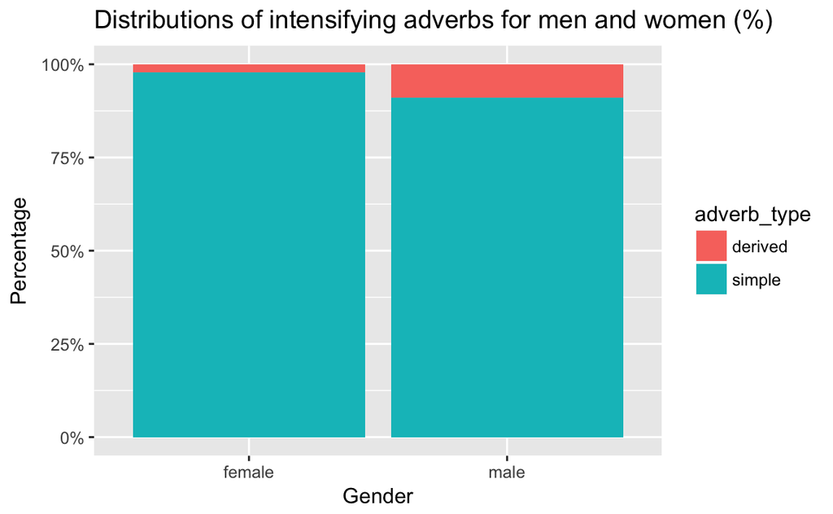

```r
ggplot(data = adverbs, aes(x = gender)) +
  geom_bar(aes(fill = adverb_type), position = "fill") +
  scale_y_continuous(labels = percent) +
  labs(x = "Gender", y = "Percentage", title = "Distributions of intensifying adverbs for men and women (%)")
```

back to top

# 3 Method

The main objective of this study is to predict the use of intensifying adverbs by fitting a logistic regression model to the data. I have chosen this method because it is appropriate for a binary target variable, i.e. the type of adverb is either ‘derived’ or ‘simple’, as well as because the explanatory variables are also mainly categorical. The complementary correspondence analysis is also well suited for this kind of data.

back to top

# 4 Results

## 4.1 Intensifying adverbs and social class

```
##
##           higher lower
##   derived    329    58
##   simple    2962  1322
```

But is the difference significant? The chi-square test confirms that it is. The p-value is very close to zero (6e-11) and we can conclude that speakers of different social classes use intensifying adverbs differently.

```
##
##  Pearson's Chi-squared test with Yates' continuity correction
##
## data:  t
## X-squared = 40, df = 1, p-value = 6e-11
```

However, there are other variables to consider as well. As we saw in section 2, these variables are not evenly distributed, and they differ in terms of adverb use.

back to top

## 4.2 Logistic regression model

```r
# reorder levels of adverb type
adverbs$adverb_type <- factor(adverbs$adverb_type, levels = c("simple", "derived"))
```

Next I will fit a logistic regression model. As the purpose of this study is to predict the use of intensifying adverbs, I will use the binary variable *adverb_type* as the target variable and set the remaining independent variables (*gender*, *year*, *class* and *role*) as the explanatory variables. Below is a summary of the fitted model.

```
##
## Call:
## glm(formula = adverb_type ~ gender + year + class + role, family = "binomial",
##     data = adverbs)
##
## Deviance Residuals:
##    Min      1Q  Median      3Q     Max
## -0.731  -0.513  -0.346  -0.253   3.118
##
## Coefficients:
##              Estimate Std. Error z value Pr(>|z|)
## (Intercept) -22.84173    4.77008   -4.79  1.7e-06 ***
## gendermale    0.91882    0.35129    2.62   0.0089 **
## year          0.01142    0.00268    4.27  2.0e-05 ***
## classlower   -0.50819    0.18233   -2.79   0.0053 **
## roleint     -12.98366  311.64922   -0.04   0.9668
## rolejud      -0.23819    0.30573   -0.78   0.4359
## rolelaw      -0.27600    0.29649   -0.93   0.3519
## roleper     -11.69850  622.83991   -0.02   0.9850
## rolevic      -0.80827    0.29460   -2.74   0.0061 **
## rolewit      -1.35128    0.28397   -4.76  2.0e-06 ***
## ---
## Signif. codes:  0 '***' 0.001 '**' 0.01 '*' 0.05 '.' 0.1 ' ' 1
##
## (Dispersion parameter for binomial family taken to be 1)
##
##     Null deviance: 2658.5  on 4666  degrees of freedom
## Residual deviance: 2489.7  on 4657  degrees of freedom
## AIC: 2510
##
## Number of Fisher Scoring iterations: 13
```

```
##                   OR    2.5 %   97.5 %
## (Intercept) 1.20e-10 9.21e-15 1.23e-06
## gendermale  2.51e+00 1.33e+00 5.37e+00
## year        1.01e+00 1.01e+00 1.02e+00
## classlower  6.02e-01 4.18e-01 8.56e-01
## roleint     2.30e-06       NA 5.98e+05
## rolejud     7.88e-01 4.40e-01 1.46e+00
## rolelaw     7.59e-01 4.32e-01 1.39e+00
## roleper     8.31e-06       NA 1.90e+37
## rolevic     4.46e-01 2.54e-01 8.09e-01
## rolewit     2.59e-01 1.51e-01 4.62e-01
```

Here are visual representations of the effects of the predictors. In order to interpret the following plots correctly, we must take into consideration the order of adverb types. The levels have been set so that ‘simple’ comes first and ‘derived’ comes second. This way ‘simple’ is interpreted as failure and ‘derived’ as success. The following figures represent the probabilities per predictor in terms of using a derived intensifier. The red bars are 95% error bars which indicate the amount of uncertainty of the predictor.

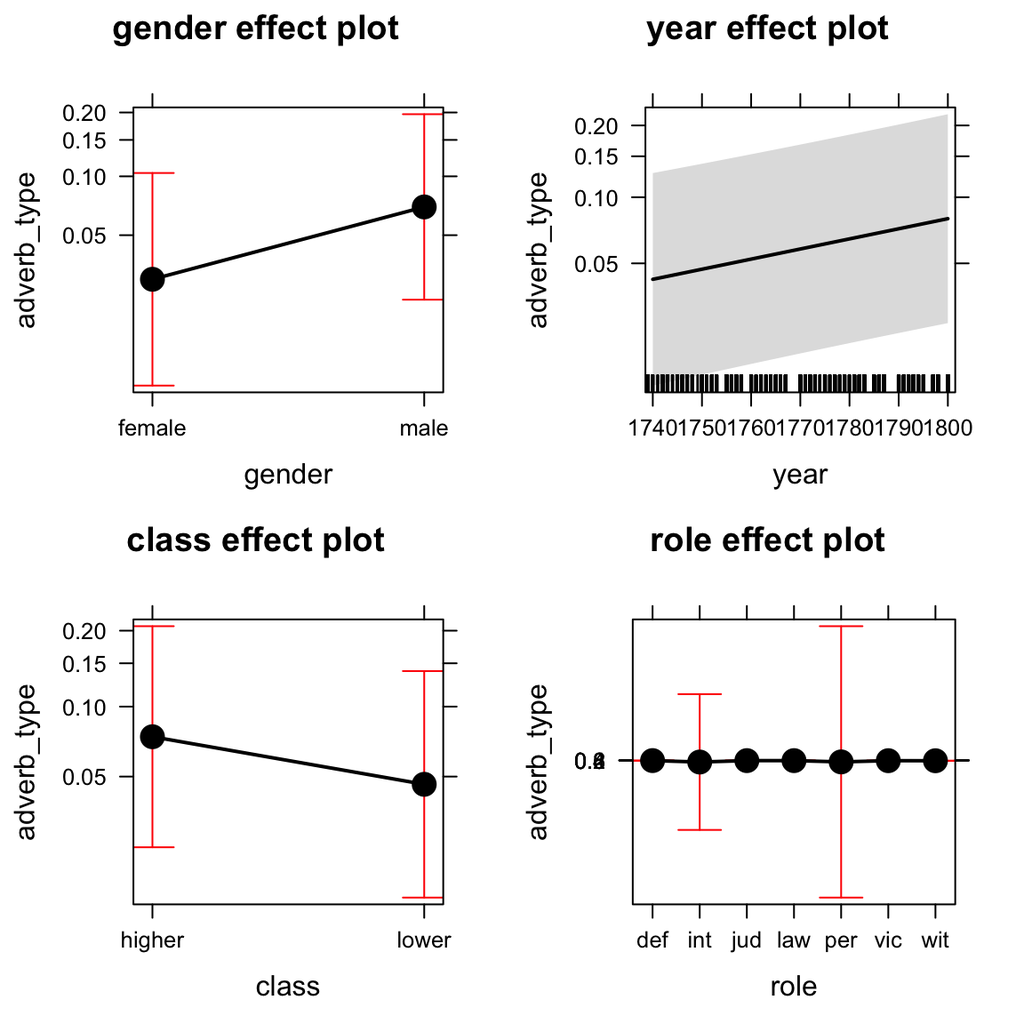

```r
# visualize effects of variables
plot(allEffects(model))
```

From these plots we can conclude that derived intensifiers are more probable if the speaker is a male (the probability for women also involves more uncertainty) who belongs to the higher social class. Furthermore, the probability increases over time. All roles have an equal probability but ‘interpreter’ and ‘person’ especially involve a very high level of uncertainty which is logical as there were only a few observations for these roles.

back to top

### 4.2.1 Prediction

```
##          prediction
## adverb     FALSE   TRUE
##   simple  0.3531 0.5644
##   derived 0.0101 0.0724
```

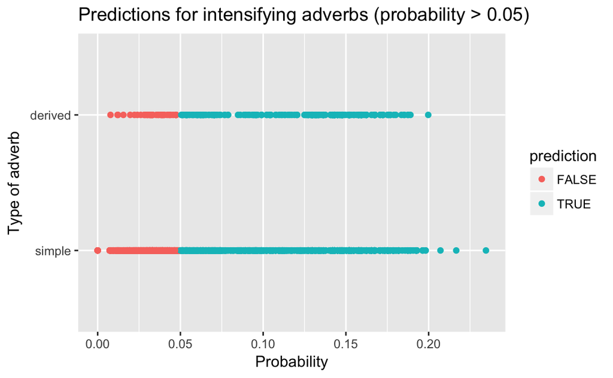

```r
# draw plot of target variable vs predictions
ggplot(adverbs, aes(x = probability, y = adverb_type, col = prediction)) +
  geom_point(aes(col = prediction)) +
  labs(x = "Probability", y = "Type of adverb", title = "Predictions for intensifying adverbs (probability > 0.05)")
```

### 4.2.2 Cross validation

```r
# loss function
loss_func <- function(class, prob) {
  n_wrong <- abs(class - prob) > 0.5
  mean(n_wrong)
}
```

Finally, in order to evaluate the model’s performance, I have calculated the average prediction error and used it to performed a 10-fold cross-validation. The numerical result represents the average number of wrong predictions so the lower it is, the better.

```r
# 10-fold cross-validation
cv <- cv.glm(data = adverbs, cost = loss_func, glmfit = model, K = 10)
cv$delta[1]
## [1] 0.0825
```

The result (0.0825) is actually pretty good, and certainly much better than I would have expected.

## 4.3 Multiple Correspondence Analysis (MCA)

Let us take a brief look of MCA. I have chosen to include this in order to confirm my findings as well as to provide a more visual representation of the data as a whole. MCA is a technique which reduces dimensions and by doing so it enables us to identify connections withing the data.

```r
# select columns for MCA (same ones as in glm)
keep <- c("adverb_type", "year", "gender", "class", "role")

# create new data frame with selected columns
adverbs_mca <- dplyr::select(adverbs, one_of(keep))

# convert year to factor
adverbs_mca$year <- factor(adverbs_mca$year)
```

First, I have converted the variable ‘year’ to factor, and then created the MCA model. Below is a summary of the model.

```
##
## Call:
## MCA(X = adverbs_mca, graph = FALSE)
##
##
## Eigenvalues
##                        Dim.1   Dim.2   Dim.3   Dim.4   Dim.5   Dim.6
## Variance               0.390   0.278   0.253   0.249   0.239   0.228
## % of var.              2.268   1.617   1.470   1.446   1.387   1.327
## Cumulative % of var.   2.268   3.885   5.355   6.801   8.188   9.515
##                        Dim.7   Dim.8   Dim.9  Dim.10  Dim.11  Dim.12
## Variance               0.226   0.220   0.207   0.200   0.200   0.200
## % of var.              1.314   1.282   1.204   1.163   1.163   1.163
## Cumulative % of var.  10.829  12.111  13.314  14.477  15.640  16.803
##                       Dim.13  Dim.14  Dim.15  Dim.16  Dim.17  Dim.18
## Variance               0.200   0.200   0.200   0.200   0.200   0.200
## % of var.              1.163   1.163   1.163   1.163   1.163   1.163
## Cumulative % of var.  17.966  19.128  20.291  21.454  22.617  23.779
##                       Dim.19  Dim.20  Dim.21  Dim.22  Dim.23  Dim.24
## Variance               0.200   0.200   0.200   0.200   0.200   0.200
## % of var.              1.163   1.163   1.163   1.163   1.163   1.163
## Cumulative % of var.  24.942  26.105  27.268  28.431  29.593  30.756
##                       Dim.25  Dim.26  Dim.27  Dim.28  Dim.29  Dim.30
## Variance               0.200   0.200   0.200   0.200   0.200   0.200
## % of var.              1.163   1.163   1.163   1.163   1.163   1.163
## Cumulative % of var.  31.919  33.082  34.245  35.407  36.570  37.733
##                       Dim.31  Dim.32  Dim.33  Dim.34  Dim.35  Dim.36
## Variance               0.200   0.200   0.200   0.200   0.200   0.200
## % of var.              1.163   1.163   1.163   1.163   1.163   1.163
## Cumulative % of var.  38.896  40.059  41.221  42.384  43.547  44.710
##                       Dim.37  Dim.38  Dim.39  Dim.40  Dim.41  Dim.42
## Variance               0.200   0.200   0.200   0.200   0.200   0.200
## % of var.              1.163   1.163   1.163   1.163   1.163   1.163
## Cumulative % of var.  45.873  47.035  48.198  49.361  50.524  51.686
##                       Dim.43  Dim.44  Dim.45  Dim.46  Dim.47  Dim.48
## Variance               0.200   0.200   0.200   0.200   0.200   0.200
## % of var.              1.163   1.163   1.163   1.163   1.163   1.163
## Cumulative % of var.  52.849  54.012  55.175  56.338  57.500  58.663
##                       Dim.49  Dim.50  Dim.51  Dim.52  Dim.53  Dim.54
## Variance               0.200   0.200   0.200   0.200   0.200   0.200
```

[output cut: 67 more lines]

```
## 1730      0.442 |   5.644   0.540   0.007   5.644 |
## 1731     -0.056 |   3.133   0.166   0.002   3.133 |
## 1732      5.255 |   0.801   0.468   0.006   5.279 |
## 1733      8.315 |   0.774   0.609   0.008   6.035 |
## 1734      6.186 |   1.097   0.571   0.007   5.824 |
## 1735      1.244 |   0.103   0.005   0.000   0.539 |
## 1736      4.938 |   0.556   0.141   0.002   2.896 |
##
## Categorical variables (eta2)
##               Dim.1 Dim.2 Dim.3
## adverb_type | 0.107 0.000 0.090 |
## year        | 0.416 0.695 0.522 |
## gender      | 0.216 0.003 0.036 |
## class       | 0.529 0.000 0.088 |
## role        | 0.682 0.692 0.528 |
```

For such limited amount of variables there are surprisingly many (86) dimensions and it is hard to find a meaningful interpretation of their eigenvalues based on the tabulation above. The following scree plot clarifies the situation much better. It plots the most influential dimensions versus percentages of explained variance explained by those dimensions. As we can see, the first dimension is clearly the most powerful one and the following ones fall somewhat far behind that level with each new dimension explaining variance less than the previous one.

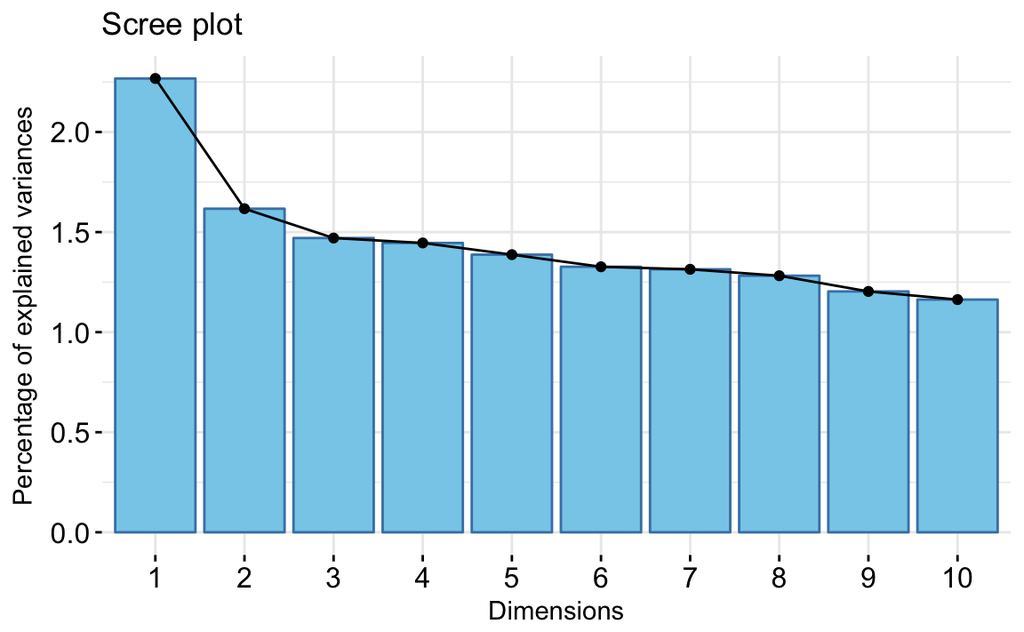

```r
fviz_screeplot(mca, barfill = "skyblue")
```

Finally, we can visualize the model using the first two dimensions. The plot below highlights the 30 categories that are best represented on those two dimensions.

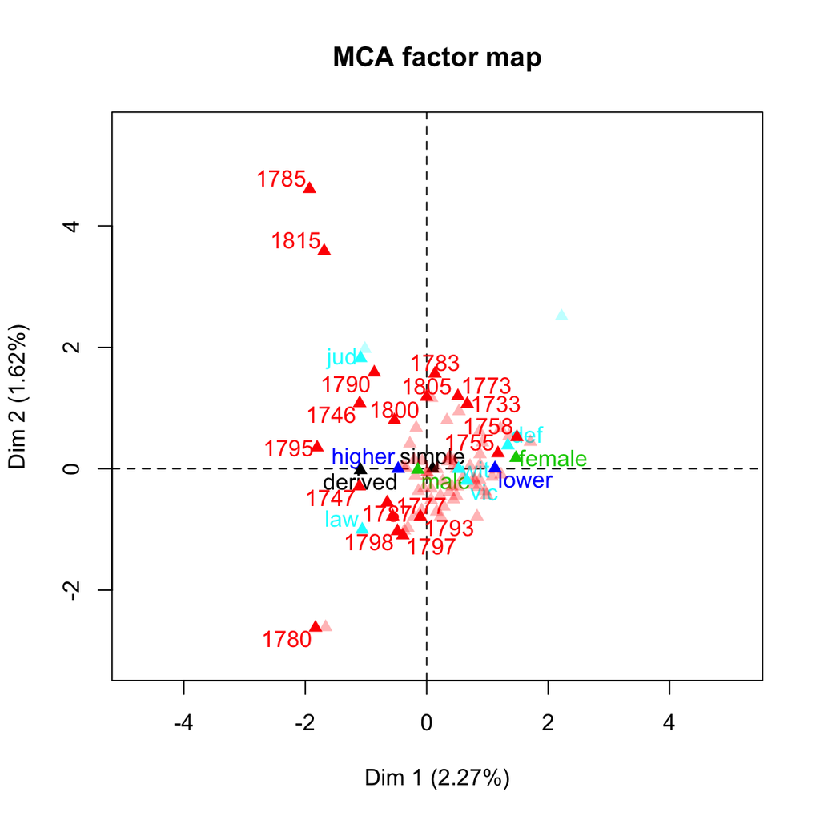

```r
# visualize MCA (top 30 categories that are best represented on the 2 dimensions)
plot(mca, invisible=c("ind"), habillage = "quali", selectMod = "cos2 30")
```

The summary above showed that the most influential variables in dimension 1 were role and class. Two roles in particular are highlighted, witness and victim, which were the most frequent ones in this data set. They are leaning towards the lower class. Lower class is associated with female speakers, and also the furthest away from derived intensifiers. Higher class is not as closely related to any particular role and is somewhere in the middle ground between the two types of intensifiers. Male speakers are very close to higher class.

Time (year) is key in both dimensions. Time is not, however, chronologically distributed along the dimensions but it would appear that some difference between 1758 and 1795 has been captured. What is most of interest is the year 1815 which is set apart by the second dimension, along with extreme instances recorded in the 1780s.

back to top

# 5 Discussion

Although the logistic model performed surprisingly well and the multiple correspondence analysis confirmed the key findings, both have to be taken with a pinch of salt - they cannot be claimed to be exhaustive representations of all linguistic behavior in this data set. As was mentioned in the beginning, the data is based on the *Proceedings* which were not complete accounts and they were subject to scribal and other kinds of interference. Also, if something has been left out, it does not mean that it did not happen, but for the researcher it is inevitably lost and must be taken into account when analyzing this kind of data. Neither should we forget the severe skewness of the data which we saw especially in the case of gender and social class - for example, there was very little data representing language spoken by higher class women. So, what the analysis has captured is the linguistic behavior of *higher class males* given the records available to us from this one source.

One of the predictor variables in the model was the speaker’s role in the courtroom. It could be argued that it is more a arbitrary variable since men and women from different social classes would have, at least to some extent, occupied different roles in the courtroom depending on the trial. So, in this way it is a more circumstantial than a descriptive variable. However, I chose to include it in the model because the official nature of the context could have brought about code switching, e.g. lower class speakers making use of the speech habits of the more prestigious higher class speakers in an attempt to add weight to what they were saying.

Finally, there is the issue of linguistic change which was, and still is, an ongoing process. Time turned out to be an influential predictor and although it did not produce a neat, linear explanation, it highlighted some interesting points in time which should be studied in more detail.

back to top

# 6 Conclusion

This study has investigated the use of intensifying adverbs in 18th-century courtroom discourse. The analysis has confirmed that there was a statistically significant relationship between the use of intensifying adverbs and social class. Although simple intensifying adverbs were by far more frequent than derived intensifying adverbs in both social classes, higher class speakers were more likely to use derived intensifiers than lower class speakers.

A logistic regression model was also fitted to the data. It revealed that social class was perhaps not the best predictor for the use of intensifying derived adverbs. Instead, time and the speaker’s role as a witness carried more weight - gender and class were not far behind but yet secondary to them. These findings were further confirmed by a multiple correspondence analysis which revealed a close relationship between male speakers and a higher social standing, which in turn was connected to the use of derived intensifiers. At the other extreme were women and a lower social status.

Due to data used and its representativeness issues, what the analysis conducted in this study has revealed is mainly the linguistic behavior of higher class male speakers in one specific context. Thus, for a more versatile view more data from other sources would be needed. Linguistic change would also need to be accounted for. One way of approaching this issue would be to divide the data into time periods and compare them to each other.

Nevertheless, considering the scarcity of data available for 18th-century spoken language, I am confident that this has been a promising beginning.

back to top

# References

Beattie, J. M. 2002. *Crime and the Courts in England 1660-1800*. Oxford: Oxford University Press.

Huber, Magnus. 2007. *The Old Bailey Proceedings, 1674-1834 - Evaluating and Annotating a Corpus of 18th- and 19th-Century Spoken English*. http://www.helsinki.fi/varieng/series/volumes/01/huber/.

Huber, Magnus, Magnus Nissel, Patrick Maiwald, and Bianca Widlitzki. 2012. *The Old Bailey Corpus. Spoken English in the 18th and 19th Centuries*. www.uni-giessen.de/oldbaileycorpus.

Langbein, John. 2005. *The Origins of Adversary Criminal Trial*. Oxford: Oxford University Press.

Macaulay, R. 2002. “Extremely Interesting, Very Interesting, or Only Quite Interesting? Adverbs and Social Class.” *Journal of Sociolinguistics* 6 (3): 398–417.